# Car Data

**Among the basic classification techniques that you are familiar with (i.e., decision tree, k-NN, logistic regression, NB, SVM) use all that would be applicable to this dataset to predict the evaluation of the cars based on their characteristics. Explore how well these techniques perform for several different parameter values. Present a brief overview of your predictive modeling process, explorations, and discuss your results. Present your final model (i.e., the best predictive model that you were able to come up with), and discuss its performance in a comprehensive manner (overall accuracy; per-class performance, i.e., whether this model predicts all classes equally well, or if there some classes for which it does much better than others; etc.).**

```python
data = pd.read_csv('car.data', names = ['buying', 'maint','doors', 'persons', 'lug_boot', 'safety', 'evaluation'])
```

```python
data.head()
```

|  | buying | maint | doors | persons | lug_boot | safety | evaluation |
| --- | --- | --- | --- | --- | --- | --- | --- |
| 0 | vhigh | vhigh | 2 | 2 | small | low | unacc |
| 1 | vhigh | vhigh | 2 | 2 | small | med | unacc |
| 2 | vhigh | vhigh | 2 | 2 | small | high | unacc |
| 3 | vhigh | vhigh | 2 | 2 | med | low | unacc |
| 4 | vhigh | vhigh | 2 | 2 | med | med | unacc |

```python
data.groupby('evaluation').size()
```

```
evaluation
acc       384
good       69
unacc    1210
vgood      65
dtype: int64
```

### 1. OneHotEncoding

We convert the categorical variables into factor variables before prediction. For this we use onehotencoder

```python
X = data.iloc[:, :6]
y = data.iloc[:,6]
```

```python
enc = OneHotEncoder()
x = enc.fit_transform(X).toarray()
```

```python
# we check the data categories by the encoder
enc.categories_
```

```
[array(['high', 'low', 'med', 'vhigh'], dtype=object),
 array(['high', 'low', 'med', 'vhigh'], dtype=object),
 array(['2', '3', '4', '5more'], dtype=object),
 array(['2', '4', 'more'], dtype=object),
 array(['big', 'med', 'small'], dtype=object),
 array(['high', 'low', 'med'], dtype=object)]
```

```python
print(y.unique())
y = y.map({'unacc':1, 'acc':2, 'good':3, 'vgood':4})
print(y.unique())
```

```
['unacc' 'acc' 'vgood' 'good']
[1 2 4 3]
```

```python
x_train, x_test, y_train, y_test = train_test_split(x, y, test_size = 0.3, random_state = 42, stratify = y)
```

```python
# We make sure the sampling in stratified
y_train.value_counts()
```

```
1    847
2    269
3     48
4     45
Name: evaluation, dtype: int64
```

### Nested GridSearch to Find Overall Best performing Model

```python
non_nested_scores = np.zeros(5)
nested_scores = np.zeros(5)

# Setting up Classifiers and parameter dictionaries
svm_params = [{'kernel': ['rbf'], 'gamma': [1e-3, 1e-4],'C': np.arange(0.01,3,0.5)},
              {'kernel': ['linear'], 'C': np.arange(0.01,3,0.5)}]
svm = SVC()

dt = DecisionTreeClassifier(random_state = 10)
dt_grid = {'max_depth':list(range(1,15)),
           'criterion':['gini', 'entropy'],
           'min_samples_split':list(range(2,15)),
           'min_samples_leaf':list(range(2,15))}

knn = KNeighborsClassifier()
knn_grid = {'n_neighbors':list(range(1,20)),
            'weights':['uniform', 'distance'],
            'algorithm':['auto', 'ball_tree', 'kd_tree', 'brute']}

logit = LogisticRegression(random_state=10, multi_class= 'multinomial', solver='saga')
lt_grid = {'penalty':['l1','l2'], 'C':list(np.arange(1, 10, 1))}

nb = MultinomialNB()
nb_grid = [{'alpha': np.arange(1,10,0.5)}]

classifiers = [logit, knn, dt, svm, nb]
dicts = [lt_grid, knn_grid, dt_grid, svm_params, nb_grid]

# Nested cross-validation
for i in range(5):
    inner_cv = KFold(n_splits=4, shuffle=True, random_state=42)
    outer_cv = KFold(n_splits=4, shuffle=True, random_state=42)

    # Non_nested parameter search and scoring
    clf = GridSearchCV(estimator=classifiers[i], param_grid=dicts[i], cv=inner_cv,iid=False, n_jobs = -1)
    clf.fit(x_train, y_train)
    non_nested_scores[i] = clf.best_score_

    # Nested CV with parameter optimization
    nested_score = cross_val_score(clf, X=x_train, y=y_train, cv=outer_cv)
    nested_scores[i] = nested_score.mean()

print(nested_scores)
```

```
[0.92307608 0.88092038 0.94953883 0.93135423 0.84618222]
```

## Decision Tree

We evaluate the performance of Decision Trees over various parameters.

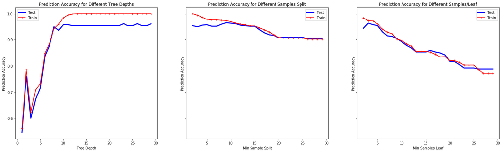

```python
dep_test_acc, dep_train_acc, samp_test_acc, samp_train_acc, leaf_test_acc, leaf_train_acc = ([] for i in range(6))

for i in range(1,30):
    dt = DecisionTreeClassifier(max_depth =i, class_weight="balanced")
    dt.fit(x_train, y_train)
    dep_test_acc.append(accuracy_score(y_test, dt.predict(x_test)))
    dep_train_acc.append(accuracy_score(y_train, dt.predict(x_train)))

for i in range(2,30):
    dt = DecisionTreeClassifier(min_samples_split=i, class_weight="balanced")
    dt.fit(x_train, y_train)
    samp_test_acc.append(accuracy_score(y_test, dt.predict(x_test)))
    samp_train_acc.append(accuracy_score(y_train, dt.predict(x_train)))

for i in range(2,30):
    dt = DecisionTreeClassifier(min_samples_leaf=i, class_weight="balanced")
    dt.fit(x_train, y_train)
    leaf_test_acc.append(accuracy_score(y_test, dt.predict(x_test)))
    leaf_train_acc.append(accuracy_score(y_train, dt.predict(x_train)))

plt.figure(figsize=(15,7))
f, (ax1, ax2, ax3) = plt.subplots(1, 3, sharey=True, figsize=(25,7))

# plt.subplots(1,2)
# plt.figure(figsize=(7,7))
ax1.plot(range(1, 30),dep_test_acc,"b-", linewidth = 3, label = "Test")
ax1.plot(range(1, 30), dep_train_acc,"r-+", linewidth = 2, label = "Train")
ax1.legend()
ax1.set_xlabel("Tree Depth")
ax1.set_ylabel("Prediction Accuracy")
ax1.set_title("Prediction Accuracy for Different Tree Depths")

ax2.plot(range(2, 30),samp_test_acc,"b-", linewidth = 3, label = "Test")
ax2.plot(range(2, 30), samp_train_acc,"r-+", linewidth = 2, label = "Train")
ax2.legend()
ax2.set_xlabel("Min Sample Split")
ax2.set_ylabel("Prediction Accuracy")
ax2.set_title("Prediction Accuracy for Different Samples Split")

ax3.plot(range(2, 30),leaf_test_acc,"b-", linewidth = 3, label = "Test")
ax3.plot(range(2, 30), leaf_train_acc,"r-+", linewidth = 2, label = "Train")
ax3.legend()
ax3.set_xlabel("Min Samples Leaf")
ax3.set_ylabel("Prediction Accuracy")
ax3.set_title("Prediction Accuracy for Different Samples/Leaf")

f.show()
```

### GridSearchCV

From above, we get the idea for how the model will behave for sevaral hyperparameters. however, we perform gridsearchCV to get the best hyperparameters for the model

We select the best model using GridSearch method. We split datasets into 5 parts to perform the cross validation. Our objective in creating the best model is to Improve the accuracy prediction.

```python
clf = DecisionTreeClassifier(random_state = 10)
p_grid = {'max_depth':list(range(1,15)),
          'criterion':['gini', 'entropy'],
          'min_samples_split':list(range(2,15)),
          'min_samples_leaf':list(range(2,15))}

classifier = GridSearchCV(clf, param_grid=p_grid, cv = 5, scoring='accuracy', n_jobs = -1)
classifier.fit(x_train, y_train)
print("Best Score:",classifier.best_score_)
print("Best Parameters:",classifier.best_params_)
```

```
Best Score: 0.9520264681555004
Best Parameters: {'criterion': 'entropy', 'max_depth': 11, 'min_samples_leaf': 3, 'min_samples_split': 2}
```

#### We then proceed to Get the model accuracy using cross validation.

```python
# Accuracy for the Parameters using Cross validation
clf = DecisionTreeClassifier(criterion='entropy', max_depth=11, min_samples_leaf = 2, min_samples_split = 2, random_state=42)
DT_Scores = cross_val_score(clf, x_train, y_train, cv = 10)

print("Mean Score:", np.mean(DT_Scores))
print("Std Deviation:", np.std(DT_Scores))
```

```
Mean Score: 0.9520542036286865
Std Deviation: 0.01793939787062026
```

#### Checking Model Performance on Holdouot Data:

```python
Decision_tree = clf.fit(x_train, y_train)
y_pred = Decision_tree.predict(x_test)

print('Confusion Matrix')
print(confusion_matrix(y_test, y_pred))
print("\n")
print(classification_report(y_test, y_pred))
```

```
Confusion Matrix
[[354   8   1   0]
 [  6 108   0   1]
 [  0   5  14   2]
 [  0   0   0  20]]


              precision    recall  f1-score   support

           1       0.98      0.98      0.98       363
           2       0.89      0.94      0.92       115
           3       0.93      0.67      0.78        21
           4       0.87      1.00      0.93        20

    accuracy                           0.96       519
   macro avg       0.92      0.90      0.90       519
weighted avg       0.96      0.96      0.96       519
```

**Decision Tree Performs Quite well with 96% accuracy**

## K - Nearest Neighbors

We evaluate the model performance across various parameters

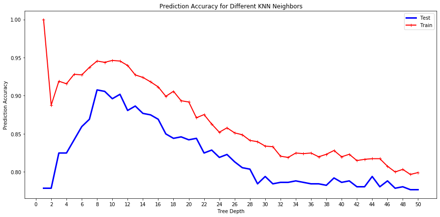

```python
test_acc = []
train_acc = []

for i in range(1,51):
    knn = KNeighborsClassifier(n_neighbors= i)
    knn.fit(x_train, y_train)
    test_acc.append(accuracy_score(y_test, knn.predict(x_test)))
    train_acc.append(accuracy_score(y_train, knn.predict(x_train)))

plt.figure(figsize=(15,7))
plt.plot(range(1, 51),test_acc,"b-", linewidth = 3, label = "Test")
plt.plot(range(1, 51), train_acc,"r-+", linewidth = 2, label = "Train")
plt.legend()
plt.xlabel("Tree Depth")
plt.ylabel("Prediction Accuracy")
plt.title("Prediction Accuracy for Different KNN Neighbors")
plt.xticks(range(0,52,2))
plt.show()
```

We observe overfitting for low number of neighbors but the model performance peaks anear 10 neighbors. However, we run a gridsearch to get the exact hyperparameters which deliver the best performance

### GridSearch

Our objective in creating the best model is to Improve theaccuracy for the prediction.

```python
clf = KNeighborsClassifier()
p_grid = {'n_neighbors':list(range(1,50)),
          'weights':['uniform', 'distance'],
          'algorithm':['auto', 'ball_tree', 'kd_tree', 'brute']}

classifier = GridSearchCV(clf, param_grid=p_grid, cv = 10, scoring='accuracy', n_jobs = -1)
classifier.fit(x_train, y_train)
print("Best Score:",classifier.best_score_)
print("Best Parameters:",classifier.best_params_)
```

```
Best Score: 0.9065343258891646
Best Parameters: {'algorithm': 'ball_tree', 'n_neighbors': 10, 'weights': 'distance'}
```

We get the best parameters for the model. We then proceed to check the model score using Cross validation and test the model on holdout data

```python
# Accuracy for the Parameters using Cross validation
clf = KNeighborsClassifier(weights = 'distance', algorithm = 'ball_tree', n_neighbors=10)
KNN_Scores = cross_val_score(clf, x_train, y_train, cv = 10)

print("Mean Score:", np.mean(KNN_Scores))
print("Std Deviation:", np.std(KNN_Scores))
```

```
Mean Score: 0.906629079992492
Std Deviation: 0.021003617807706952
```

#### Checking Model Performance on Holdouot Data:

```python
clf.fit(x_train, y_train)
y_pred = clf.predict(x_test)
print('Confusion Matrix')
print(confusion_matrix(y_test, y_pred))
print('\n')
print(classification_report(y_test, y_pred))
```

```
Confusion Matrix
[[363   0   0   0]
 [ 29  86   0   0]
 [  0  13   7   1]
 [  0   8   1  11]]


              precision    recall  f1-score   support

           1       0.93      1.00      0.96       363
           2       0.80      0.75      0.77       115
           3       0.88      0.33      0.48        21
           4       0.92      0.55      0.69        20

    accuracy                           0.90       519
   macro avg       0.88      0.66      0.73       519
weighted avg       0.90      0.90      0.89       519
```

## Logistic Regression

Comparing model performance for different values for hyperparameter

### GridSearch

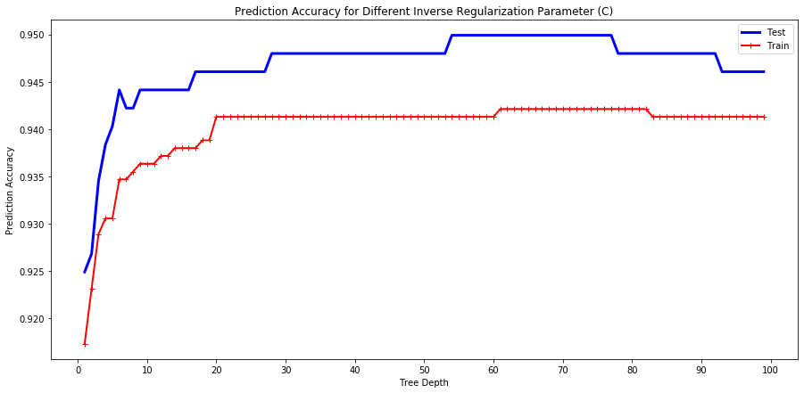

```python
test_acc = []
train_acc = []

for i in range(1,100):
    Logit = LogisticRegression(C= i, multi_class= 'multinomial', solver='lbfgs', max_iter = 10000)
    Logit.fit(x_train, y_train)
    test_acc.append(accuracy_score(y_test, Logit.predict(x_test)))
    train_acc.append(accuracy_score(y_train, Logit.predict(x_train)))

plt.figure(figsize=(15,7))
plt.plot(range(1, 100),test_acc,"b-", linewidth = 3, label = "Test")
plt.plot(range(1, 100), train_acc,"r-+", linewidth = 2, label = "Train")
plt.legend()
plt.xlabel("Tree Depth")
plt.ylabel("Prediction Accuracy")
plt.title("Prediction Accuracy for Different Inverse Regularization Parameter (C)")
plt.xticks(range(0,102,10))
plt.show()
```

### GridSearch

Our objective in creating the best model is to Improve the **Accuracy**.

```python
clf = LogisticRegression(random_state=10, multi_class= 'multinomial', solver='saga')
p_grid = {'penalty':['l1','l2', 'none'], 'C':list(np.arange(1.0, 10.0, 0.2))}

classifier = GridSearchCV(clf, param_grid=p_grid, cv = 10, scoring='accuracy', n_jobs = -1)
classifier.fit(x_train, y_train)
print("Best Score:",classifier.best_score_)
print("Best Parameters:",classifier.best_params_)
```

```
Best Score: 0.9280397022332506
Best Parameters: {'C': 1.0, 'penalty': 'none'}
```

From Gridsearch, we get the best hyperparameters for the model.

#### We then proceed to Get the model accuracy using cross validation.

```python
# Accuracy for the Parameters using Cross validation
clf = LogisticRegression(penalty = 'none', C = 1, multi_class= 'multinomial', solver='saga')
Logistic_Scores = cross_val_score(clf, x_train, y_train, cv = 10)

print("Mean Score:", np.mean(Logistic_Scores))
print("Std Deviation:", np.std(Logistic_Scores))
```

```
Mean Score: 0.9278985471344496
Std Deviation: 0.036374163582958884
```

#### Checking Model Performance on Holdouot Data:

```python
clf.fit(x_train, y_train)
y_pred = clf.predict(x_test)
print('Confusion Matrix')
print(confusion_matrix(y_test, y_pred))
print('\n')
print(classification_report(y_test, y_pred))
```

```
Confusion Matrix
[[353  10   0   0]
 [  8 103   1   3]
 [  0   4  15   2]
 [  0   0   0  20]]


              precision    recall  f1-score   support

           1       0.98      0.97      0.98       363
           2       0.88      0.90      0.89       115
           3       0.94      0.71      0.81        21
           4       0.80      1.00      0.89        20

    accuracy                           0.95       519
   macro avg       0.90      0.90      0.89       519
weighted avg       0.95      0.95      0.95       519
```

## SVM Classifier

We Check Model performance with SVC.

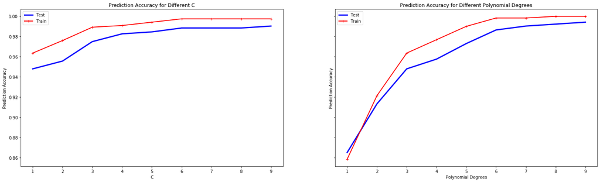

```python
test_acc1, train_acc1, test_acc2, train_acc2 = ([] for i in range(4))

for i in range(1,10):
    Machine = SVC(kernel="poly", degree=3, coef0=1, C=i)
    Machine.fit(x_train, y_train)
    test_acc1.append(accuracy_score(y_test, Machine.predict(x_test)))
    train_acc1.append(accuracy_score(y_train, Machine.predict(x_train)))

for i in range(1,10):
    Machine = SVC(kernel="poly", degree=i, coef0=1, C=1)
    Machine.fit(x_train, y_train)
    test_acc2.append(accuracy_score(y_test, Machine.predict(x_test)))
    train_acc2.append(accuracy_score(y_train, Machine.predict(x_train)))

plt.figure(figsize=(15,7))
f, (ax1, ax2) = plt.subplots(1, 2, sharey=True, figsize=(25,7))

ax1.plot(range(1, 10),test_acc1,"b-", linewidth = 3, label = "Test")
ax1.plot(range(1, 10),train_acc1,"r-+", linewidth = 2, label = "Train")
ax1.legend()
ax1.set_xlabel("C")
ax1.set_ylabel("Prediction Accuracy")
ax1.set_title("Prediction Accuracy for Different C")

ax2.plot(range(1, 10),test_acc2,"b-", linewidth = 3, label = "Test")
ax2.plot(range(1, 10),train_acc2,"r-+", linewidth = 2, label = "Train")
ax2.legend()
ax2.set_xlabel("Polynomial Degrees")
ax2.set_ylabel("Prediction Accuracy")
ax2.set_title("Prediction Accuracy for Different Polynomial Degrees")

plt.show()
```

### GridSearch

```python
params = [{'kernel': ['rbf'], 'gamma': [1e-3, 1e-4],'C': np.arange(0.01,3,0.5)},
          {'kernel': ['linear'], 'C': np.arange(0.01,3,0.5)},
          {'kernel': ['poly'], 'C': np.arange(0.01,3,0.5), 'degree': np.arange(1, 6, 1), 'coef0':np.arange(0,3,0.5)}]

Machine = SVC()
classifier = GridSearchCV(Machine, param_grid= params, cv = 5, scoring = "accuracy", n_jobs = -1)
classifier.fit(x_train, y_train)
print("Best Score:",classifier.best_score_)
print("Best Parameters:",classifier.best_params_)
```

```
Best Score: 0.9950372208436724
Best Parameters: {'C': 0.51, 'coef0': 2.5, 'degree': 5, 'kernel': 'poly'}
```

### Performing Cross Validation to get optimum model performance

```python
# Accuracy for the Parameters using Cross validation
clf = SVC(C = 2.51, kernel = 'poly', coef0 = 1.5, degree = 5)
SVM_Scores = cross_val_score(clf, x_train, y_train, cv = 10)

print("Mean Score:", np.mean(SVM_Scores))
print("Std Deviation:", np.std(SVM_Scores))
```

```
Mean Score: 0.9552358888875532
Std Deviation: 0.02668092489976188
```

#### Checking Model Performance on Holdouot Data:

```python
clf.fit(x_train, y_train)
y_pred = clf.predict(x_test)
print('Confusion Matrix')
print(confusion_matrix(y_test, y_pred))
print('\n')
print(classification_report(y_test, y_pred))
```

```
Confusion Matrix
[[362   1   0   0]
 [  0 115   0   0]
 [  0   1  20   0]
 [  0   0   0  20]]


              precision    recall  f1-score   support

           1       1.00      1.00      1.00       363
           2       0.98      1.00      0.99       115
           3       1.00      0.95      0.98        21
           4       1.00      1.00      1.00        20

    accuracy                           1.00       519
   macro avg       1.00      0.99      0.99       519
weighted avg       1.00      1.00      1.00       519
```

The SVM Classification has the best prediction accuracy of 99%  
The model only misclassifies 2 observations and has a perfect score os class 1 and 4.

## Naive Bayes Classifier

We Check Model performance

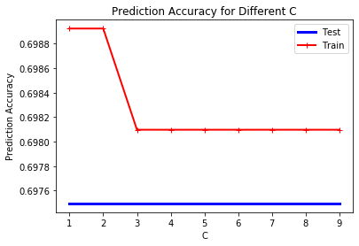

```python
test_acc1, train_acc1 = ([] for i in range(2))

for i in range(1,10):
    Machine = MultinomialNB(alpha = i)
    Machine.fit(x_train, y_train)
    test_acc1.append(accuracy_score(y_test, Machine.predict(x_test)))
    train_acc1.append(accuracy_score(y_train, Machine.predict(x_train)))

plt.plot(range(1, 10),test_acc1,"b-", linewidth = 3, label = "Test")
plt.plot(range(1, 10),train_acc1,"r-+", linewidth = 2, label = "Train")
plt.legend()
plt.xlabel("C")
plt.ylabel("Prediction Accuracy")
plt.title("Prediction Accuracy for Different C")
plt.show()
```

### GridSearch

```python
params = [{'alpha': np.arange(1,10,0.5)}]
Machine = MultinomialNB()
classifier = GridSearchCV(Machine, param_grid= params, cv = 5, scoring = "accuracy", n_jobs = -1)
classifier.fit(x_train, y_train)
print("Best Score:",classifier.best_score_)
print("Best Parameters:",classifier.best_params_)
```

```
Best Score: 0.6989247311827957
Best Parameters: {'alpha': 1.0}
```

### Performing Cross Validation to get optimum model performance

```python
# Accuracy for the Parameters using Cross validation
clf = MultinomialNB(alpha = 1)
SVM_Scores = cross_val_score(clf, x_train, y_train, cv = 10)

print("Mean Score:", np.mean(SVM_Scores))
print("Std Deviation:", np.std(SVM_Scores))
```

```
Mean Score: 0.6989714198640586
Std Deviation: 0.006796816541406042
```

#### Checking Model Performance on Holdouot Data:

```python
clf.fit(x_train, y_train)
y_pred = clf.predict(x_test)
print('Confusion Matrix')
print(confusion_matrix(y_test, y_pred))
print('\n')
print(classification_report(y_test, y_pred))
```

```
Confusion Matrix
[[362   1   0   0]
 [115   0   0   0]
 [ 18   3   0   0]
 [ 17   3   0   0]]


              precision    recall  f1-score   support

           1       0.71      1.00      0.83       363
           2       0.00      0.00      0.00       115
           3       0.00      0.00      0.00        21
           4       0.00      0.00      0.00        20

    accuracy                           0.70       519
   macro avg       0.18      0.25      0.21       519
weighted avg       0.49      0.70      0.58       519
```

The Naive Bayes Classification has the best prediction accuracy of 70%. The classifier predicts majority to be class 1

## **Using Categorical Variable**

```python
data = pd.read_csv('car.data', names = ['buying', 'maint','doors', 'persons', 'lug_boot', 'safety', 'evaluation'])
```

```python
data.head()
```

|  | buying | maint | doors | persons | lug_boot | safety | evaluation |
| --- | --- | --- | --- | --- | --- | --- | --- |
| 0 | vhigh | vhigh | 2 | 2 | small | low | unacc |
| 1 | vhigh | vhigh | 2 | 2 | small | med | unacc |
| 2 | vhigh | vhigh | 2 | 2 | small | high | unacc |
| 3 | vhigh | vhigh | 2 | 2 | med | low | unacc |
| 4 | vhigh | vhigh | 2 | 2 | med | med | unacc |

```python
data.groupby('evaluation').size()
```

```
evaluation
acc       384
good       69
unacc    1210
vgood      65
dtype: int64
```

```python
print('Unique Variables (buying):',data['buying'].unique())
data['buying_num'] = data['buying'].map({'vhigh':4, 'high':3, 'med':2, 'low':1})
print('Converting to Ordinal (buying):', data['buying_num'].unique())

print('\n')

print('Unique Variables (maint):',data['maint'].unique())
data['maint_num'] = data['maint'].map({'vhigh':4, 'high':3, 'med':2, 'low':1})
print('Converting to Ordinal (maint):', data['maint_num'].unique())

print('\n')

print('Unique Variables (lug_boot):',data['lug_boot'].unique())
data['lug_boot_num'] = data['lug_boot'].map({'big':3, 'med':2, 'small':1})
print('Converting to Ordinal (lug_boot):', data['lug_boot_num'].unique())

print('\n')

print('Unique Variables (safety):',data['safety'].unique())
data['safety_num'] = data['safety'].map({'high':3, 'med':2, 'low':1})
print('Converting to Ordinal (safety_boot):', data['safety_num'].unique())

print('\n')

print('Unique Variables (evaluation):',data['evaluation'].unique())
data['evaluation_num'] = data['evaluation'].map({'vgood':4, 'good':3, 'acc':2, 'unacc':1})
print('Converting to Ordinal (evaluation_boot):', data['evaluation_num'].unique())

print('\n')

print('Unique Variables (doors):',data['doors'].unique())
data['doors_num'] = data['doors'].map({'2':2, '3':3, '4':4, '5more':5})
print('Converting to Ordinal (doors):', data['doors_num'].unique())

print('\n')

print('Unique Variables (persons):',data['persons'].unique())
data['persons_num'] = data['persons'].map({'2':2, '4':4, 'more':6})
print('Converting to Ordinal (persons):', data['persons_num'].unique())
```

```
Unique Variables (buying): ['vhigh' 'high' 'med' 'low']
Converting to Ordinal (buying): [4 3 2 1]


Unique Variables (maint): ['vhigh' 'high' 'med' 'low']
Converting to Ordinal (maint): [4 3 2 1]


Unique Variables (lug_boot): ['small' 'med' 'big']
Converting to Ordinal (lug_boot): [1 2 3]


Unique Variables (safety): ['low' 'med' 'high']
Converting to Ordinal (safety_boot): [1 2 3]


Unique Variables (evaluation): ['unacc' 'acc' 'vgood' 'good']
Converting to Ordinal (evaluation_boot): [1 2 4 3]


Unique Variables (doors): ['2' '3' '4' '5more']
Converting to Ordinal (doors): [2 3 4 5]


Unique Variables (persons): ['2' '4' 'more']
Converting to Ordinal (persons): [2 4 6]
```

```python
data.head()
```

|  | buying | maint | doors | persons | lug_boot | safety | evaluation | buying_num | maint_num | lug_boot_num | safety_num | evaluation_num | doors_num | persons_num |
| --- | --- | --- | --- | --- | --- | --- | --- | --- | --- | --- | --- | --- | --- | --- |
| 0 | vhigh | vhigh | 2 | 2 | small | low | unacc | 4 | 4 | 1 | 1 | 1 | 2 | 2 |
| 1 | vhigh | vhigh | 2 | 2 | small | med | unacc | 4 | 4 | 1 | 2 | 1 | 2 | 2 |
| 2 | vhigh | vhigh | 2 | 2 | small | high | unacc | 4 | 4 | 1 | 3 | 1 | 2 | 2 |
| 3 | vhigh | vhigh | 2 | 2 | med | low | unacc | 4 | 4 | 2 | 1 | 1 | 2 | 2 |
| 4 | vhigh | vhigh | 2 | 2 | med | med | unacc | 4 | 4 | 2 | 2 | 1 | 2 | 2 |

```python
x = data[['buying_num', 'maint_num', 'lug_boot_num', 'doors_num', 'persons_num', 'safety_num']]
y = data[['evaluation_num']]
```

```python
x.shape
```

```
(1728, 6)
```

```python
x_train, x_test, y_train, y_test = train_test_split(x, y, test_size = 0.3, random_state = 42, stratify = y)
```

### Nested GridSearch to Find Overall Best performing Model

```python
non_nested_scores = np.zeros(4)
nested_scores = np.zeros(4)

# Setting up Classifiers and parameter dictionaries
svm_params = [{'kernel': ['rbf'], 'gamma': [1e-3, 1e-4],'C': np.arange(0.01,3,0.5)},
              {'kernel': ['linear'], 'C': np.arange(0.01,3,0.5)}]
svm = SVC()

dt = DecisionTreeClassifier(random_state = 10)
dt_grid = {'max_depth':list(range(1,15)),
           'criterion':['gini', 'entropy'],
           'min_samples_split':list(range(2,15)),
           'min_samples_leaf':list(range(2,15))}

knn = KNeighborsClassifier()
knn_grid = {'n_neighbors':list(range(1,20)),
            'weights':['uniform', 'distance'],
            'algorithm':['auto', 'ball_tree', 'kd_tree', 'brute']}

logit = LogisticRegression(random_state=10, multi_class= 'multinomial', solver='saga')
lt_grid = {'penalty':['l1','l2'], 'C':list(np.arange(1, 10, 1))}

nb = MultinomialNB()
nb_grid = [{'alpha': np.arange(1,10,0.5)}]

classifiers = [logit, knn, dt, svm, nb]
dicts = [lt_grid, knn_grid, dt_grid, svm_params, nb_grid]

# Nested cross-validation
for i in range(4):
    inner_cv = KFold(n_splits=4, shuffle=True, random_state=42)
    outer_cv = KFold(n_splits=4, shuffle=True, random_state=42)

    # Non_nested parameter search and scoring
    clf = GridSearchCV(estimator=classifiers[i], param_grid=dicts[i], cv=inner_cv,iid=False, n_jobs = -1)
    clf.fit(x_train, y_train)
    non_nested_scores[i] = clf.best_score_

    # Nested CV with parameter optimization
    nested_score = cross_val_score(clf, X=x_train, y=y_train, cv=outer_cv)
    nested_score[i] = nested_score.mean()


print(nested_score)
```

```
[0.84158416 0.86092715 0.85430464 0.85443577]
```

```python
nested_score
```

```
array([0.84158416, 0.86092715, 0.85430464, 0.85443577])
```

## Decision Tree

We evaluate the performance of Decision Trees over various parameters.

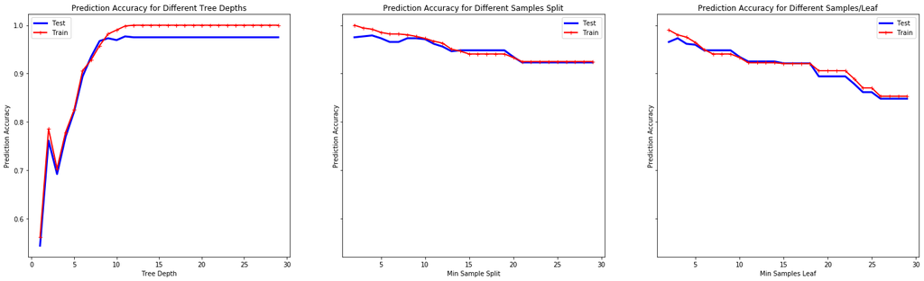

```python
dep_test_acc, dep_train_acc, samp_test_acc, samp_train_acc, leaf_test_acc, leaf_train_acc = ([] for i in range(6))

for i in range(1,30):
    dt = DecisionTreeClassifier(max_depth =i, class_weight="balanced")
    dt.fit(x_train, y_train)
    dep_test_acc.append(accuracy_score(y_test, dt.predict(x_test)))
    dep_train_acc.append(accuracy_score(y_train, dt.predict(x_train)))

for i in range(2,30):
    dt = DecisionTreeClassifier(min_samples_split=i, class_weight="balanced")
    dt.fit(x_train, y_train)
    samp_test_acc.append(accuracy_score(y_test, dt.predict(x_test)))
    samp_train_acc.append(accuracy_score(y_train, dt.predict(x_train)))

for i in range(2,30):
    dt = DecisionTreeClassifier(min_samples_leaf=i, class_weight="balanced")
    dt.fit(x_train, y_train)
    leaf_test_acc.append(accuracy_score(y_test, dt.predict(x_test)))
    leaf_train_acc.append(accuracy_score(y_train, dt.predict(x_train)))

plt.figure(figsize=(15,7))
f, (ax1, ax2, ax3) = plt.subplots(1, 3, sharey=True, figsize=(25,7))

# plt.subplots(1,2)
# plt.figure(figsize=(7,7))
ax1.plot(range(1, 30),dep_test_acc,"b-", linewidth = 3, label = "Test")
ax1.plot(range(1, 30), dep_train_acc,"r-+", linewidth = 2, label = "Train")
ax1.legend()
ax1.set_xlabel("Tree Depth")
ax1.set_ylabel("Prediction Accuracy")
ax1.set_title("Prediction Accuracy for Different Tree Depths")

ax2.plot(range(2, 30),samp_test_acc,"b-", linewidth = 3, label = "Test")
ax2.plot(range(2, 30), samp_train_acc,"r-+", linewidth = 2, label = "Train")
ax2.legend()
ax2.set_xlabel("Min Sample Split")
ax2.set_ylabel("Prediction Accuracy")
ax2.set_title("Prediction Accuracy for Different Samples Split")

ax3.plot(range(2, 30),leaf_test_acc,"b-", linewidth = 3, label = "Test")
ax3.plot(range(2, 30), leaf_train_acc,"r-+", linewidth = 2, label = "Train")
ax3.legend()
ax3.set_xlabel("Min Samples Leaf")
ax3.set_ylabel("Prediction Accuracy")
ax3.set_title("Prediction Accuracy for Different Samples/Leaf")

f.show()
```

### GridSearchCV

From above, we get the idea for how the model will behave for sevaral hyperparameters. however, we perform gridsearchCV to get the best hyperparameters for the model

We select the best model using GridSearch method. We split datasets into 5 parts to perform the cross validation. Our objective in creating the best model is to Improve the accuracy prediction.

```python
clf = DecisionTreeClassifier(random_state = 10)
p_grid = {'max_depth':list(range(1,15)),
          'criterion':['gini', 'entropy'],
          'min_samples_split':list(range(2,15)),
          'min_samples_leaf':list(range(2,15))}

classifier = GridSearchCV(clf, param_grid=p_grid, cv = 5, scoring='accuracy', n_jobs = -1)
classifier.fit(x_train, y_train)
print("Best Score:",classifier.best_score_)
print("Best Parameters:",classifier.best_params_)
```

```
Best Score: 0.9619520264681555
Best Parameters: {'criterion': 'entropy', 'max_depth': 11, 'min_samples_leaf': 2, 'min_samples_split': 2}
```

#### We then proceed to Get the model accuracy using cross validation.

```python
# Accuracy for the Parameters using Cross validation
clf = DecisionTreeClassifier(criterion='entropy', max_depth=11, min_samples_leaf = 2, min_samples_split = 2)
DT_Scores = cross_val_score(clf, x_train, y_train, cv = 10)

print("Mean Score:", np.mean(DT_Scores))
print("Std Deviation:", np.std(DT_Scores))
```

```
Mean Score: 0.976801533532061
Std Deviation: 0.009712306912835776
```

#### Checking Model Performance on Holdouot Data:

```python
Decision_tree = clf.fit(x_train, y_train)
y_pred = Decision_tree.predict(x_test)

print('Confusion Matrix')
print(confusion_matrix(y_test, y_pred))
print("\n")
print(classification_report(y_test, y_pred))
```

```
Confusion Matrix
[[357   5   1   0]
 [ 12 102   1   0]
 [  0   6  13   2]
 [  0   2   1  17]]


              precision    recall  f1-score   support

           1       0.97      0.98      0.98       363
           2       0.89      0.89      0.89       115
           3       0.81      0.62      0.70        21
           4       0.89      0.85      0.87        20

    accuracy                           0.94       519
   macro avg       0.89      0.83      0.86       519
weighted avg       0.94      0.94      0.94       519
```

## K - Nearest Neighbors

We evaluate the model performance across various parameters

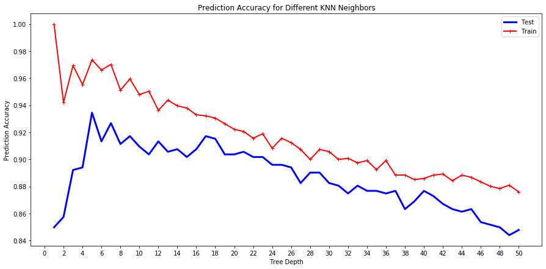

```python
test_acc = []
train_acc = []

for i in range(1,51):
    knn = KNeighborsClassifier(n_neighbors= i)
    knn.fit(x_train, y_train)
    test_acc.append(accuracy_score(y_test, knn.predict(x_test)))
    train_acc.append(accuracy_score(y_train, knn.predict(x_train)))

plt.figure(figsize=(15,7))
plt.plot(range(1, 51),test_acc,"b-", linewidth = 3, label = "Test")
plt.plot(range(1, 51), train_acc,"r-+", linewidth = 2, label = "Train")
plt.legend()
plt.xlabel("Tree Depth")
plt.ylabel("Prediction Accuracy")
plt.title("Prediction Accuracy for Different KNN Neighbors")
plt.xticks(range(0,52,2))
plt.show()
```

We observe overfitting for low number of neighbors but the model performance peaks near 5 neighbors. However, we run a gridsearch to get the exact hyperparameters which deliver the best performance

### GridSearch

Our objective in creating the best model is to Improve theaccuracy for the prediction.

```python
clf = KNeighborsClassifier()
p_grid = {'n_neighbors':list(range(1,50)),
          'weights':['uniform', 'distance'],
          'algorithm':['auto', 'ball_tree', 'kd_tree', 'brute']}

classifier = GridSearchCV(clf, param_grid=p_grid, cv = 10, scoring='accuracy', n_jobs = -1)
classifier.fit(x_train, y_train)
print("Best Score:",classifier.best_score_)
print("Best Parameters:",classifier.best_params_)
```

```
Best Score: 0.9404466501240695
Best Parameters: {'algorithm': 'auto', 'n_neighbors': 5, 'weights': 'distance'}
```

We get the best parameters for the model. We then proceed to check the model score using Cross validation and test the model on holdout data

```python
# Accuracy for the Parameters using Cross validation
clf = KNeighborsClassifier(weights = 'distance', algorithm = 'auto', n_neighbors=5)
KNN_Scores = cross_val_score(clf, x_train, y_train, cv = 10)

print("Mean Score:", np.mean(KNN_Scores))
print("Std Deviation:", np.std(KNN_Scores))
```

```
Mean Score: 0.9404890162867312
Std Deviation: 0.01194396629957086
```

#### Checking Model Performance on Holdouot Data:

```python
clf.fit(x_train, y_train)
y_pred = clf.predict(x_test)
print('Confusion Matrix')
print(confusion_matrix(y_test, y_pred))
print('\n')
print(classification_report(y_test, y_pred))
```

```
Confusion Matrix
[[356   7   0   0]
 [  9 105   1   0]
 [  0  11  10   0]
 [  0   4   1  15]]


              precision    recall  f1-score   support

           1       0.98      0.98      0.98       363
           2       0.83      0.91      0.87       115
           3       0.83      0.48      0.61        21
           4       1.00      0.75      0.86        20

    accuracy                           0.94       519
   macro avg       0.91      0.78      0.83       519
weighted avg       0.94      0.94      0.93       519
```

## Logistic Regression

Comparing model performance for different values for hyperparameter

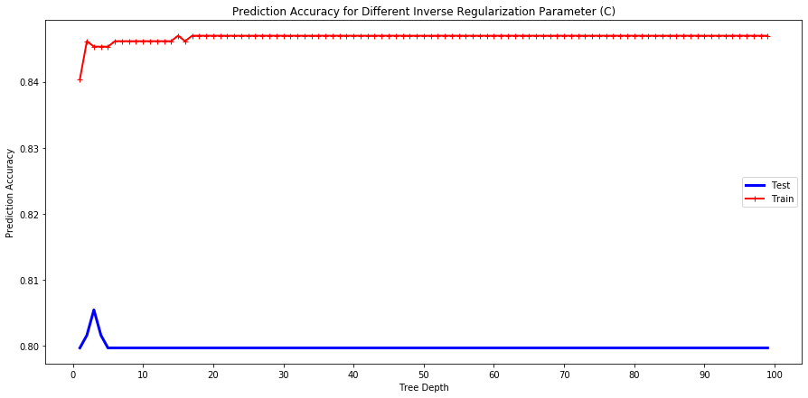

```python
test_acc = []
train_acc = []

for i in range(1,100):
    Logit = LogisticRegression(C= i, multi_class= 'multinomial', solver='lbfgs', max_iter = 10000)
    Logit.fit(x_train, y_train)
    test_acc.append(accuracy_score(y_test, Logit.predict(x_test)))
    train_acc.append(accuracy_score(y_train, Logit.predict(x_train)))

plt.figure(figsize=(15,7))
plt.plot(range(1, 100),test_acc,"b-", linewidth = 3, label = "Test")
plt.plot(range(1, 100), train_acc,"r-+", linewidth = 2, label = "Train")
plt.legend()
plt.xlabel("Tree Depth")
plt.ylabel("Prediction Accuracy")
plt.title("Prediction Accuracy for Different Inverse Regularization Parameter (C)")
plt.xticks(range(0,102,10))
plt.show()
```

### GridSearch

Our objective in creating the best model is to Improve the **Accuracy**.

```python
clf = LogisticRegression(random_state=10, multi_class= 'multinomial', solver='lbfgs', max_iter = 10000)
p_grid = {'penalty':['l2', 'none'], 'C':list(np.arange(1.0, 10.0, 0.2))}

classifier = GridSearchCV(clf, param_grid=p_grid, cv = 10, scoring='accuracy', n_jobs = -1)
classifier.fit(x_train, y_train)
print("Best Score:",classifier.best_score_)
print("Best Parameters:",classifier.best_params_)
```

```
Best Score: 0.8444995864350703
Best Parameters: {'C': 1.0, 'penalty': 'none'}
```

From Gridsearch, we get the best hyperparameters for the model.

#### We then proceed to Get the model accuracy using cross validation.

```python
# Accuracy for the Parameters using Cross validation
clf = LogisticRegression(penalty = 'none', C = 1, multi_class= 'multinomial', solver='lbfgs', max_iter = 10000)
Logistic_Scores = cross_val_score(clf, x_train, y_train, cv = 10)

print("Mean Score:", np.mean(Logistic_Scores))
print("Std Deviation:", np.std(Logistic_Scores))
```

```
Mean Score: 0.8443895070422567
Std Deviation: 0.04036355695171179
```

#### Checking Model Performance on Holdouot Data:

```python
clf.fit(x_train, y_train)
y_pred = clf.predict(x_test)
print('Confusion Matrix')
print(confusion_matrix(y_test, y_pred))
print('\n')
print(classification_report(y_test, y_pred))
```

```
Confusion Matrix
[[333  23   5   2]
 [ 48  62   2   3]
 [  2  12   7   0]
 [  0   7   0  13]]


              precision    recall  f1-score   support

           1       0.87      0.92      0.89       363
           2       0.60      0.54      0.57       115
           3       0.50      0.33      0.40        21
           4       0.72      0.65      0.68        20

    accuracy                           0.80       519
   macro avg       0.67      0.61      0.64       519
weighted avg       0.79      0.80      0.79       519
```

## SVM Classifier

We Check Model performance with SVC.

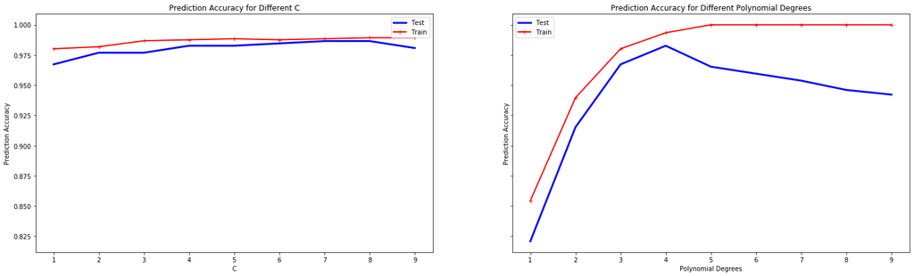

```python
test_acc1, train_acc1, test_acc2, train_acc2 = ([] for i in range(4))

for i in range(1,10):
    Machine = SVC(kernel="poly", degree=3, coef0=1, C=i)
    Machine.fit(x_train, y_train)
    test_acc1.append(accuracy_score(y_test, Machine.predict(x_test)))
    train_acc1.append(accuracy_score(y_train, Machine.predict(x_train)))

for i in range(1,10):
    Machine = SVC(kernel="poly", degree=i, coef0=1, C=1)
    Machine.fit(x_train, y_train)
    test_acc2.append(accuracy_score(y_test, Machine.predict(x_test)))
    train_acc2.append(accuracy_score(y_train, Machine.predict(x_train)))

plt.figure(figsize=(15,7))
f, (ax1, ax2) = plt.subplots(1, 2, sharey=True, figsize=(25,7))

ax1.plot(range(1, 10),test_acc1,"b-", linewidth = 3, label = "Test")
ax1.plot(range(1, 10),train_acc1,"r-+", linewidth = 2, label = "Train")
ax1.legend()
ax1.set_xlabel("C")
ax1.set_ylabel("Prediction Accuracy")
ax1.set_title("Prediction Accuracy for Different C")

ax2.plot(range(1, 10),test_acc2,"b-", linewidth = 3, label = "Test")
ax2.plot(range(1, 10),train_acc2,"r-+", linewidth = 2, label = "Train")
ax2.legend()
ax2.set_xlabel("Polynomial Degrees")
ax2.set_ylabel("Prediction Accuracy")
ax2.set_title("Prediction Accuracy for Different Polynomial Degrees")

plt.show()
```

### GridSearch

```python
params = [{'kernel': ['rbf'], 'gamma': [1e-3, 1e-4],'C': np.arange(0.01,3,0.5)},
          {'kernel': ['linear'], 'C': np.arange(0.01,3,0.5)},
          {'kernel': ['poly'], 'C': np.arange(0.01,3,0.5), 'degree': np.arange(1, 6, 1), 'coef0':np.arange(0,3,0.5)}]

Machine = SVC()
classifier = GridSearchCV(Machine, param_grid= params, cv = 5, scoring = "accuracy", n_jobs = -1)
classifier.fit(x_train, y_train)
print("Best Score:",classifier.best_score_)
print("Best Parameters:",classifier.best_params_)
```

```
Best Score: 0.9619520264681555
Best Parameters: {'C': 0.01, 'coef0': 2.0, 'degree': 5, 'kernel': 'poly'}
```

### Performing Cross Validation to get optimum model performance

```python
# Accuracy for the Parameters using Cross validation
clf = SVC(C = 0.01, kernel = 'poly', coef0 = 2, degree = 5)
SVM_Scores = cross_val_score(clf, x_train, y_train, cv = 10)

print("Mean Score:", np.mean(SVM_Scores))
print("Std Deviation:", np.std(SVM_Scores))
```

```
Mean Score: 0.9702380827112407
Std Deviation: 0.021631642263773704
```

#### Checking Model Performance on Holdouot Data:

```python
clf.fit(x_train, y_train)
y_pred = clf.predict(x_test)
print('Confusion Matrix')
print(confusion_matrix(y_test, y_pred))
print('\n')
print(classification_report(y_test, y_pred))
```

```
Confusion Matrix
[[361   2   0   0]
 [  0 115   0   0]
 [  0   3  18   0]
 [  0   1   0  19]]


              precision    recall  f1-score   support

           1       1.00      0.99      1.00       363
           2       0.95      1.00      0.97       115
           3       1.00      0.86      0.92        21
           4       1.00      0.95      0.97        20

    accuracy                           0.99       519
   macro avg       0.99      0.95      0.97       519
weighted avg       0.99      0.99      0.99       519
```

## Naive Bayes Classifier

We Check Model performance

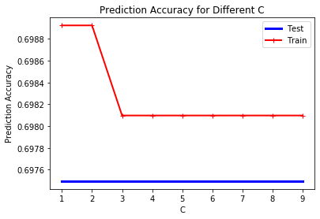

```python
test_acc1, train_acc1 = ([] for i in range(2))

for i in range(1,10):
    Machine = MultinomialNB(alpha = i)
    Machine.fit(x_train, y_train)
    test_acc1.append(accuracy_score(y_test, Machine.predict(x_test)))
    train_acc1.append(accuracy_score(y_train, Machine.predict(x_train)))

plt.plot(range(1, 10),test_acc1,"b-", linewidth = 3, label = "Test")
plt.plot(range(1, 10),train_acc1,"r-+", linewidth = 2, label = "Train")
plt.legend()
plt.xlabel("C")
plt.ylabel("Prediction Accuracy")
plt.title("Prediction Accuracy for Different C")
plt.show()
```

### GridSearch

```python
params = [{'alpha': np.arange(1,10,0.5)}]
Machine = MultinomialNB()
classifier = GridSearchCV(Machine, param_grid= params, cv = 5, scoring = "accuracy", n_jobs = -1)
classifier.fit(x_train, y_train)
print("Best Score:",classifier.best_score_)
print("Best Parameters:",classifier.best_params_)
```

```
Best Score: 0.6989247311827957
Best Parameters: {'alpha': 1.0}
```

### Performing Cross Validation to get optimum model performance

```python
# Accuracy for the Parameters using Cross validation
clf = MultinomialNB(alpha = 1)
SVM_Scores = cross_val_score(clf, x_train, y_train, cv = 10)

print("Mean Score:", np.mean(SVM_Scores))
print("Std Deviation:", np.std(SVM_Scores))
```

```
Mean Score: 0.6989714198640586
Std Deviation: 0.006796816541406042
```

#### Checking Model Performance on Holdouot Data:

```python
clf.fit(x_train, y_train)
y_pred = clf.predict(x_test)
print('Confusion Matrix')
print(confusion_matrix(y_test, y_pred))
print('\n')
print(classification_report(y_test, y_pred))
```

```
Confusion Matrix
[[362   1   0   0]
 [115   0   0   0]
 [ 18   3   0   0]
 [ 17   3   0   0]]


              precision    recall  f1-score   support

           1       0.71      1.00      0.83       363
           2       0.00      0.00      0.00       115
           3       0.00      0.00      0.00        21
           4       0.00      0.00      0.00        20

    accuracy                           0.70       519
   macro avg       0.18      0.25      0.21       519
weighted avg       0.49      0.70      0.58       519
```

The Naive Bayes Classification has the best prediction accuracy of 70%. The classifier predicts majority to be class 1

### Comparing Categorical and OneHotEncoded model Performances

| Model Performance (Accuracy) | Categorical | OnehotEncoded |
| --- | --- | --- |
| **Decision Tree** | 94% | 96% |
| **KNN Classifier** | 94% | 90% |
| **Logistic Regression** | 80% | 95% |
| **SVM Classifier** | 98.84% | 99.61% |
| **Naive Bayes** | 70% | 70% |

Upon further research for differences between the two appraoaches we see the following differences:

| Method | Pros | Cons |
| --- | --- | --- |
| Numerical (using OneHotEncoder) | Can Compare between levels of categories which do not have a magniture to them | Increases the cmputational time and the complexity of the model. |
| **Categorical** | Less Computational Complexity Variables with multiple levels can drastically increase dataset size. | Cannot compare between various variable levels. We do not know the relative magnitude difference between the two variables. |